# From IPython to Jupyter

... how the attempt to make the standard Python console better lead to a new ecosystem for interactive computing, with support of multiple languages, ... and also how this relates to a big money and at least one legend programmer.

## Overview

- What is Jupyter
- A bit of history
- Structure
- Usage
- Extensions
- Future?

http://jupyter.org/index.html

[figure not shown]

http://jupyter.org/index.html

> The Jupyter Notebook is a web application that allows you to create and share documents that contain live code, equations, visualizations and explanatory text. Uses include: data cleaning and transformation, numerical simulation, statistical modeling, machine learning and much more.

https://talkpython.fm/episodes/show/44/project-jupyter-and-ipython

> - Interactive computing
> - Reproducible research
> - Software-based communication

# Simplest example

Let's plot the function

$$y = \frac{sin(\pi x)}{\pi x}$$

for $x$ in $[-2.0, 2.0]$

```python
import numpy as np
from matplotlib import pyplot as plt

%matplotlib inline
```

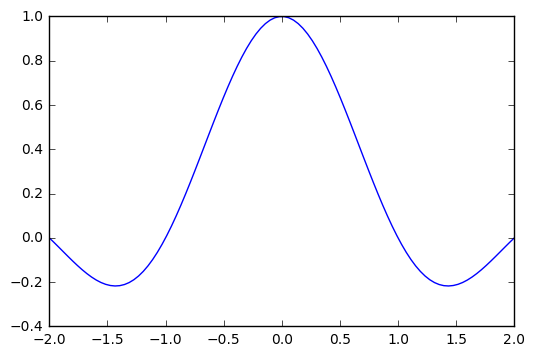

```python
x = np.linspace(-2.0, 2.0, 100)
y = np.sinc(x)

plt.plot(x, y)
```

# History

http://blog.fperez.org/2012/01/ipython-notebook-historical.html

- 2001 - IPython 0.0.1, https://gist.github.com/fperez/1579699
- 2006-2007 - First notebook attempt (similar to Sage)
- 2011 - Qt console, Kernel/UI separation
- December 2011 - IPython Notebook was added to IPython in the 0.12 release
- 2014 - Project Jupyter (big split)

> As of IPython 4.0, the language-agnostic parts of the project: the notebook format, message protocol, qtconsole, notebook web application, etc. have moved to new projects under the name Jupyter. IPython itself is focused on interactive Python, part of which is providing a Python kernel for Jupyter.

Influenced by: Wolfram Mathematica, Maple, MathCad

# Structure

[figure not shown]

https://jupyter.readthedocs.io/en/latest/architecture/how_jupyter_ipython_work.html

# Structure

- IPython
- ØMQ, http://zeromq.org/
- Tornado, http://www.tornadoweb.org
- jQuery, https://jquery.com/
- Bootstrap, http://getbootstrap.com/
- MathJax, https://www.mathjax.org/
- `.ipynb`, JSON format

## Projects

https://github.com/ipython/ipython/wiki/Projects-using-IPython

# Languages

https://github.com/ipython/ipython/wiki/IPython%20kernels%20for%20other%20languages

Custom kernel:

- Protocol implementation or wrapper
- UI for free

Not only dynamic languages

Cython, e.g.: https://www.youtube.com/watch?v=aVriaZJDHks

# Big Money # 1: ZMQ

- Started as a AMQP (http://www.amqp.org/) implementation

  > a financial industry attempt to standardize the wire protocol for business messaging
- Final implementation: BSD socket 'on steroids'

http://www.aosabook.org/en/zeromq.html

# Legend Programmer

[figure not shown]

http://www-cs-staff.stanford.edu/~uno/

## Art of Computer Programming

[figure not shown]

By http://www.amazon.com/Art-Computer-Programming-Fundamental-Algorithms/dp/0201896834

## TeX

`The quadratic formula is $$-b \pm \sqrt{b^2 - 4ac} \over 2a$$`

The quadratic formula is $$-b \pm \sqrt{b^2 - 4ac} \over 2a$$

https://en.wikipedia.org/wiki/TeX

## Literate Programming

```
 The grand totals must be initialized to zero at the beginning of the program.
If we made these variables local to main, we would have to do this  initialization
explicitly; however, C globals are automatically zeroed. (Or rather,``statically
zeroed.'' (Get it?)

    <<Global variables>>+=
    long tot_word_count, tot_line_count,
         tot_char_count;
      /* total number of words, lines, chars */
    @
```

https://en.wikipedia.org/wiki/Literate_programming

# IPython/Jupyter idea

- Literate computing
- Reproducible research
- Notebook as Excel replacement

http://blog.fperez.org/2013/04/literate-computing-and-computational.html

# Usage

`pip install jupyter`

Anaconda: built-in

`jupyter notebook --port 80`

# Try

[figure not shown]

https://try.jupyter.org/

[figure not shown]

# nbviewer

[figure not shown]

https://nbviewer.jupyter.org/

# Keyboard

- `Shift`+`Enter`: run cell, select below
- `Ctrl`+`Enter`: run selected cells
- `Alt`+`Enter`: run cell, insert below
- `Ctrl`+`S`: Save and Checkpoint

## Command mode

- `H`: help
- `Enter`: edit mode

## Edit mode

- `Esc`: command mode
- `Tab`: code completion or indent

List is extended from time to time

# History: Inputs/Outputs

- `_i`, `_ii`, `_iii`: store previous, next previous and next-next previous inputs
- `In`, `_ih`: a list of all inputs
- `_` (a single underscore): stores previous output, like Python’s default interpreter
- `__` (two underscores): next previous
- `___` (three underscores): next-next previous
- `_21`: 21st output
- `Out`, or `_oh`: list of all outputs

http://ipython.readthedocs.io/en/stable/interactive/reference.html

# Magic commands

```python
%lsmagic
```

```
Available line magics:
%alias  %alias_magic  %autocall  %automagic  %autosave  %bookmark  %cd  %clear  %cls  %colors  %config  %connect_info  %copy  %ddir  %debug  %dhist  %dirs  %doctest_mode  %echo  %ed  %edit  %env  %gui  %hist  %history  %killbgscripts  %ldir  %less  %load  %load_ext  %loadpy  %logoff  %logon  %logsta…

Available cell magics:
%%!  %%HTML  %%SVG  %%bash  %%capture  %%cmd  %%debug  %%file  %%html  %%javascript  %%js  %%latex  %%perl  %%prun  %%pypy  %%python  %%python2  %%python3  %%ruby  %%script  %%sh  %%svg  %%sx  %%system  %%time  %%timeit  %%writefile

Automagic is ON, % prefix IS NOT needed for line magics.
```

# Magic commands

- `%who` - line magic
- `%%timeit` - cell magic
- `!echo` - OS shell command

# Getting help

```python
%pdb??
```

```
Source:
    @line_magic
    def pdb(self, parameter_s=''):
        """Control the automatic calling of the pdb interactive debugger.

        Call as '%pdb on', '%pdb 1', '%pdb off' or '%pdb 0'. If called without
        argument it works as a toggle.

        When an exception is triggered, IPython can optionally call the
        interactive pdb debugger after the traceback printout. %pdb toggles
        this feature on and off.

        The initial state of this feature is set in your configuration
        file (the option is ``InteractiveShell.pdb``).
...
```

```python
np.all?
```

```
Signature: np.all(a, axis=None, out=None, keepdims=False)
Docstring:
Test whether all array elements along a given axis evaluate to True.

Parameters
----------
a : array_like
    Input array or object that can be converted to an array.
axis : None or int or tuple of ints, optional
    Axis or axes along which a logical AND reduction is performed.
    The default (`axis` = `None`) is to perform a logical AND over all
    the dimensions of the input array. `axis` may be negative, in
    which case it counts from the last to the first axis.
...
```

# Slides

**Idea:** Notebooks are just JSON files

- `jupyter nbconvert "From IPython to Jupyter.ipynb" --to slides --post serve`
- Special cell types
- `reveal.js`, https://github.com/hakimel/reveal.js/
- Example: http://www.slideviper.oquanta.info/tutorial/slideshow_tutorial_slides.html
- Intro: http://www.damian.oquanta.info/posts/make-your-slides-with-ipython.html
- Custom templates: http://www.damian.oquanta.info/posts/customizing-your-ipython-slides.html
- Templating: http://www.damian.oquanta.info/posts/change-the-ipython-slides-defaults-with-an-ipython-config-file.html
- `nbconvert` doc: http://nbconvert.readthedocs.io/en/latest/usage.html

# Blogs

https://jakevdp.github.io/blog/2015/08/14/out-of-core-dataframes-in-python/

[figure not shown]

...

[figure not shown]

# Books

[figure not shown]

http://ipython-books.github.io/

# Docs, intro

- https://jupyter.readthedocs.io/
  - Work in progress
  - Many parts from IPython
- Project docs
  - http://jupyter-notebook.readthedocs.io/
  - http://jupyter_console.readthedocs.io/
  - https://qtconsole.readthedocs.io/
  - https://ipywidgets.readthedocs.io/
  - https://ipyparallel.readthedocs.io/
  - ...
- http://arogozhnikov.github.io/2016/09/10/jupyter-features.html

# Interact

## Live demo

# Future

Too much going on, just some ideas...

# Jupyter Hub

[figure not shown]

http://jupyterhub.readthedocs.io/en/latest/

# JupyterLab

[figure not shown]

https://blog.jupyter.org/2016/07/14/jupyter-lab-alpha/

# Big Money # 2

https://www.techatbloomberg.com/blog/inside-the-collaboration-that-built-the-open-source-jupyterlab-project/

[figure not shown]

https://github.com/bloomberg/bqplot

# Jupyter Incubator

[figure not shown]

https://github.com/jupyter-incubator/dashboards

# Thank you

Nikolay Karelin

skype:nkarelin

Slides: https://github.com/karelin/meetup_jupyter